# Colour frequencies and climate

Fabian C. Salgado-Roa

2023-10-17

# Colour frequencies and climate

load inputs and library

```r
library(tidyverse)
load("input_freq_analyses.rda")

sites_freq<-sites_freq[,names(sites_freq)!="females_cream"]
```

Function to calculate pairwise locatyion distance based on relative frequency of morphs

```r
dist_morph_freq<-function(data,localities,morphs,method="euclidean"){
#make sure the data is a data frame
data<-as.data.frame(data)
# localities unique values
localities<-unique(localities)
#create empty template
rownames(data)<-localities
comparisons<-expand.grid(localities,localities)
#generate empty matrix
result_guide <- matrix(NA, nrow = length(unique(comparisons$Var1)), ncol = length(unique(comparisons$Var1)))
rownames(result_guide) <- colnames(result_guide) <- unique(comparisons$Var1)
#
comparisons$value<-NA
for(cmp in 1:nrow(comparisons)){
#locations to compare
locA<-as.vector(comparisons[cmp,"Var1"])
locB<-as.vector(comparisons[cmp,"Var2"])
#If it is the same locality move to the next
if(locA==locB){
    comparisons[cmp,"value"]<-0
    result_guide[locA,locB]<-0
    next
}
#counter
value<-0
count_morphs<-1
while(count_morphs<length(morphs)){
locA_total<-sum(data[locA,morphs])
locB_total<-sum(data[locB,morphs])
#difference in freq
tmp_diff<-(data[locA,morphs[count_morphs]]/locA_total)-(data[locB,morphs[count_morphs]]/locB_total)
#apply the formula
tmp_val<-tmp_diff^2
#add the value
value<-sum(value,tmp_val)
#move to the next morph
count_morphs<-count_morphs+1
}
#When finished add the final value to the dataframe and matrix
comparisons[cmp,"value"]<-sqrt(value)
result_guide[locA,locB]<-sqrt(value)
result_guide[locB,locA]<-sqrt(value)
}
result_list<-list(result_guide,comparisons)
names(result_list)<-c("square_matrix","pair_comp")
return(result_list)
}
```

## Association between colour frequency and not correlated climatic variables

Let’s explore the regressions with the two datasets used, AWAP and Chelsa, making pairwise comparisons and all the morphs. We will use not correlated variables based on the results obtained on the file *dates_activity_climaticdata.md*

### Chelsa Multiple Regression on distance Matrices

The independent variables are:

-Precipitation -Minimum temperature

#### Model with all morphs

```r
result_dist_freq<-dist_morph_freq(data=sites_freq,localities=sites_freq$locality,morphs=c("females_orange","females_black","females_white"))
set.seed(65456)
multiple_reg_model<-ecodist::MRM(as.dist(scale(result_dist_freq$square_matrix))~as.dist(scale(dis_geo))+as.dist(scale(dist(sites_freq$chelsa_pr)))+as.dist(scale(dist(sites_freq$chelsa_tasmin))),method = "linear",nperm = 100000,mrank = FALSE)

multiple_reg_model
```

```
## $coef
##                                                as.dist(scale(result_dist_freq$square_matrix))
## Int                                                                               -0.01935895
## as.dist(scale(dis_geo))                                                           -0.01505204
## as.dist(scale(dist(sites_freq$chelsa_pr)))                                         0.07876392
## as.dist(scale(dist(sites_freq$chelsa_tasmin)))                                     0.02862574
##                                                   pval
## Int                                            0.95887
## as.dist(scale(dis_geo))                        0.48397
## as.dist(scale(dist(sites_freq$chelsa_pr)))     0.07158
## as.dist(scale(dist(sites_freq$chelsa_tasmin))) 0.37513
##
## $r.squared
##         R2       pval
## 0.00658799 0.13986000
##
## $F.test
##        F   F.pval
## 2.590776 0.139860
```

#### Model black vs orange

```r
result_dist_freq<-dist_morph_freq(data=sites_freq,localities=sites_freq$locality,morphs=c("females_orange","females_black"))
#geodistance
dis_geo<-geosphere::distm(as.matrix(sites_freq[,c("X","Y")]),fun=geosphere::distGeo)

multiple_reg_model_BvO<-ecodist::MRM(as.dist(scale(result_dist_freq$square_matrix))~as.dist(scale(dis_geo))+as.dist(scale(dist(sites_freq$chelsa_pr)))+as.dist(scale(dist(sites_freq$chelsa_tasmin))),method = "linear",nperm = 100000,mrank = FALSE)

multiple_reg_model_BvO
```

[output not shown]

#### Model black vs white

```r
result_dist_freq<-dist_morph_freq(data=sites_freq,localities=sites_freq$locality,morphs=c("females_white","females_black"))
#geodistance
dis_geo<-geosphere::distm(as.matrix(sites_freq[,c("X","Y")]),fun=geosphere::distGeo)

multiple_reg_model_BvW<-ecodist::MRM(as.dist(scale(result_dist_freq$square_matrix))~as.dist(scale(dis_geo))+as.dist(scale(dist(sites_freq$chelsa_pr)))+as.dist(scale(dist(sites_freq$chelsa_tasmin))),method = "linear",nperm = 100000,mrank = FALSE)

multiple_reg_model_BvW
```

```
## $coef
##                                                as.dist(scale(result_dist_freq$square_matrix))
## Int                                                                                0.02381600
## as.dist(scale(dis_geo))                                                            0.00392163
## as.dist(scale(dist(sites_freq$chelsa_pr)))                                         0.04430318
## as.dist(scale(dist(sites_freq$chelsa_tasmin)))                                     0.06152223
##                                                   pval
## Int                                            0.07174
## as.dist(scale(dis_geo))                        0.87066
## as.dist(scale(dist(sites_freq$chelsa_pr)))     0.34346
## as.dist(scale(dist(sites_freq$chelsa_tasmin))) 0.10022
##
## $r.squared
##          R2        pval
## 0.004359433 0.248120000
##
## $F.test
##        F   F.pval
## 1.710542 0.248120
```

None of the variable influences the change in colour frequency between Black and black-and-white morph

#### Model orange vs white

```r
result_dist_freq<-dist_morph_freq(data=sites_freq,localities=sites_freq$locality,morphs=c("females_white","females_orange"))
#geodistance
dis_geo<-geosphere::distm(as.matrix(sites_freq[,c("X","Y")]),fun=geosphere::distGeo)

multiple_reg_model_OvW<-ecodist::MRM(as.dist(scale(result_dist_freq$square_matrix))~as.dist(scale(dis_geo))+as.dist(scale(dist(sites_freq$chelsa_pr)))+as.dist(scale(dist(sites_freq$chelsa_tasmin))),method = "linear",nperm = 100000,mrank = FALSE)

multiple_reg_model_OvW
```

```
## $coef
##                                                as.dist(scale(result_dist_freq$square_matrix))
## Int                                                                               -0.03306794
## as.dist(scale(dis_geo))                                                           -0.05080649
## as.dist(scale(dist(sites_freq$chelsa_pr)))                                         0.15211344
## as.dist(scale(dist(sites_freq$chelsa_tasmin)))                                    -0.03428533
##                                                   pval
## Int                                            0.99087
## as.dist(scale(dis_geo))                        0.00668
## as.dist(scale(dist(sites_freq$chelsa_pr)))     0.00110
## as.dist(scale(dist(sites_freq$chelsa_tasmin))) 0.17179
##
## $r.squared
##         R2       pval
## 0.04211498 0.00103000
##
## $F.test
##        F   F.pval
## 17.17630  0.00103
```

Precipitation seems to be the variable that influences the change in colour frequency between Black-and-white and Orange morphs

### AWAP Multiple Regression on distance Matrices

#### Model with all morphs

```r
result_dist_freq<-dist_morph_freq(data=sites_freq,localities=sites_freq$locality,morphs=c("females_orange","females_black","females_white"))
set.seed(65456)
multiple_reg_model<-ecodist::MRM(as.dist(scale(result_dist_freq$square_matrix))~as.dist(scale(dis_geo))+as.dist(scale(dist(sites_freq$precipitation)))+as.dist(scale(dist(sites_freq$max_temperature)))+as.dist(scale(dist(sites_freq$min_temperature))),method = "linear",nperm = 100000,mrank = FALSE)

multiple_reg_model
```

```
## $coef
##                                                  as.dist(scale(result_dist_freq$square_matrix))
## Int                                                                                -0.024905440
## as.dist(scale(dis_geo))                                                             0.004678289
## as.dist(scale(dist(sites_freq$precipitation)))                                      0.135586715
## as.dist(scale(dist(sites_freq$max_temperature)))                                   -0.057791197
## as.dist(scale(dist(sites_freq$min_temperature)))                                    0.008992608
##                                                     pval
## Int                                              0.64240
## as.dist(scale(dis_geo))                          0.82947
## as.dist(scale(dist(sites_freq$precipitation)))   0.00282
## as.dist(scale(dist(sites_freq$max_temperature))) 0.14562
## as.dist(scale(dist(sites_freq$min_temperature))) 0.85243
##
## $r.squared
##         R2       pval
## 0.02238534 0.06405000
##
## $F.test
##        F   F.pval
## 6.703364 0.064050
```

Precipitation seem to be the variable that influences the change in colour frequency between locations

#### Model black vs orange

```r
result_dist_freq<-dist_morph_freq(data=sites_freq,localities=sites_freq$locality,morphs=c("females_orange","females_black"))
#geodistance
dis_geo<-geosphere::distm(as.matrix(sites_freq[,c("X","Y")]),fun=geosphere::distGeo)

multiple_reg_model_BvO<-ecodist::MRM(as.dist(scale(result_dist_freq$square_matrix))~as.dist(scale(dis_geo))+as.dist(scale(dist(sites_freq$precipitation)))+as.dist(scale(dist(sites_freq$min_temperature)))+as.dist(scale(dist(sites_freq$max_temperature))),method = "linear",nperm = 100000,mrank = FALSE)

multiple_reg_model_BvO
```

[output not shown]

Precipitation seem to be the variable that influences the change in colour frequency between Black and Orange morph

#### Model black vs white

```r
result_dist_freq<-dist_morph_freq(data=sites_freq,localities=sites_freq$locality,morphs=c("females_white","females_black"))
#geodistance
dis_geo<-geosphere::distm(as.matrix(sites_freq[,c("X","Y")]),fun=geosphere::distGeo)

multiple_reg_model_BvW<-ecodist::MRM(as.dist(scale(result_dist_freq$square_matrix))~as.dist(scale(dis_geo))+as.dist(scale(dist(sites_freq$precipitation)))+as.dist(scale(dist(sites_freq$min_temperature)))+as.dist(scale(dist(sites_freq$max_temperature))),method = "linear",nperm = 100000,mrank = FALSE)

multiple_reg_model_BvW
```

```
## $coef
##                                                  as.dist(scale(result_dist_freq$square_matrix))
## Int                                                                                  0.02161727
## as.dist(scale(dis_geo))                                                              0.01607330
## as.dist(scale(dist(sites_freq$precipitation)))                                       0.08774603
## as.dist(scale(dist(sites_freq$min_temperature)))                                     0.03259077
## as.dist(scale(dist(sites_freq$max_temperature)))                                    -0.06316726
##                                                     pval
## Int                                              0.19374
## as.dist(scale(dis_geo))                          0.50784
## as.dist(scale(dist(sites_freq$precipitation)))   0.05101
## as.dist(scale(dist(sites_freq$min_temperature))) 0.53466
## as.dist(scale(dist(sites_freq$max_temperature))) 0.14996
##
## $r.squared
##          R2        pval
## 0.009416523 0.211350000
##
## $F.test
##        F   F.pval
## 2.782892 0.211350
```

none of the variables affect the frequency change between the Black and black-and-white morph

#### Model orange vs white

```r
result_dist_freq<-dist_morph_freq(data=sites_freq,localities=sites_freq$locality,morphs=c("females_white","females_orange"))
#geodistance
dis_geo<-geosphere::distm(as.matrix(sites_freq[,c("X","Y")]),fun=geosphere::distGeo)

multiple_reg_model_OvW<-ecodist::MRM(as.dist(scale(result_dist_freq$square_matrix))~as.dist(scale(dis_geo))+as.dist(scale(dist(sites_freq$precipitation)))+as.dist(scale(dist(sites_freq$min_temperature)))+as.dist(scale(dist(sites_freq$max_temperature))),method = "linear",nperm = 100000,mrank = FALSE)

multiple_reg_model_OvW
```

```
## $coef
##                                                  as.dist(scale(result_dist_freq$square_matrix))
## Int                                                                                 -0.04740549
## as.dist(scale(dis_geo))                                                             -0.01576021
## as.dist(scale(dist(sites_freq$precipitation)))                                       0.16802488
## as.dist(scale(dist(sites_freq$min_temperature)))                                    -0.05180497
## as.dist(scale(dist(sites_freq$max_temperature)))                                    -0.01435881
##                                                     pval
## Int                                              0.02698
## as.dist(scale(dis_geo))                          0.35528
## as.dist(scale(dist(sites_freq$precipitation)))   0.00001
## as.dist(scale(dist(sites_freq$min_temperature))) 0.19461
## as.dist(scale(dist(sites_freq$max_temperature))) 0.62535
##
## $r.squared
##         R2       pval
## 0.06141217 0.00587000
##
## $F.test
##        F   F.pval
## 19.15475  0.00587
```

Precipitation influences the change in colour frequency between Black-and-white and Orange morphs

## Linear models morph relative frequency vs climatic variables

Considering that the frequency is a bounded variable, let’s use a logit transformation

```r
logit<-function(var){res<-(var+0.01)/(1-(var+0.01))
  return(log(res))
}
```

### Chelsa Linear models significant variables

Calculate frequencies relative frequencies

```r
relative_freq<-data.frame(females_white=numeric(),females_orange=numeric(),females_black=numeric())
morphs<-c("females_white","females_orange","females_black")
for(i in 1:nrow(sites_freq)){
total<-sum(sites_freq[i,morphs])
freq<-as.numeric(sites_freq[i,morphs]/total)
relative_freq[i,]<-freq
}
```

add a column with the precipitation and minimum temperature

```r
relative_freq[relative_freq==0]<-NA
relative_freq$precipitation<-sites_freq$chelsa_pr
relative_freq$tasmin<-sites_freq$chelsa_tasmin
```

linear models per colour morph

#### black morph

```r
lm_black<-lm(logit(females_black)~precipitation+tasmin,data=relative_freq)
summary(lm_black)
```

```
##
## Call:
## lm(formula = logit(females_black) ~ precipitation + tasmin, data = relative_freq)
##
## Residuals:
##      Min       1Q   Median       3Q      Max
## -2.08302 -0.95743 -0.04338  0.79698  2.67034
##
## Coefficients:
##                Estimate Std. Error t value Pr(>|t|)
## (Intercept)   -60.63353   29.09928  -2.084   0.0442 *
## precipitation   1.21048    0.48152   2.514   0.0164 *
## tasmin          0.01678    0.01043   1.609   0.1161
## ---
## Signif. codes:  0 '***' 0.001 '**' 0.01 '*' 0.05 '.' 0.1 ' ' 1
##
## Residual standard error: 1.153 on 37 degrees of freedom
##   (9 observations deleted due to missingness)
## Multiple R-squared:  0.2452, Adjusted R-squared:  0.2044
## F-statistic: 6.009 on 2 and 37 DF,  p-value: 0.005496
```

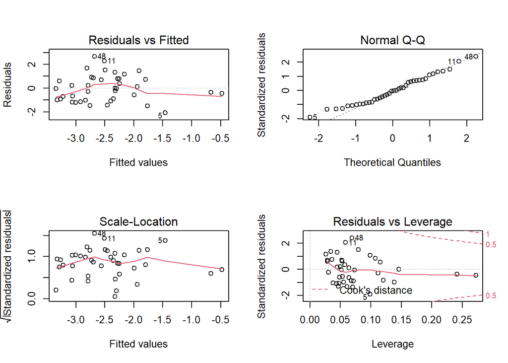

```r
par(mfrow=c(2,2))
plot(lm_black)
```

```r
anova(lm_black)
```

|  | Df | Sum Sq | Mean Sq | F value | Pr(>F) |
| --- | --- | --- | --- | --- | --- |
| precipitation | 1 | 12.541288 | 12.541288 | 9.430112 | 0.003987435 |
| tasmin | 1 | 3.442598 | 3.442598 | 2.588577 | 0.116137620 |
| Residuals | 37 | 49.207016 | 1.329919 | NA | NA |

#### white-black morph

```r
lm_white<-lm(logit(females_white)~precipitation+tasmin,data=relative_freq)
summary(lm_white)
```

```
##
## Call:
## lm(formula = logit(females_white) ~ precipitation + tasmin, data = relative_freq)
##
## Residuals:
##     Min      1Q  Median      3Q     Max
## -2.9546 -0.9139 -0.3529  0.6606  4.7659
##
## Coefficients:
##                Estimate Std. Error t value Pr(>|t|)
## (Intercept)   16.668601  42.583529   0.391    0.698
## precipitation -0.873040   0.703101  -1.242    0.223
## tasmin        -0.002443   0.015237  -0.160    0.874
##
## Residual standard error: 1.632 on 34 degrees of freedom
##   (12 observations deleted due to missingness)
## Multiple R-squared:  0.05027,    Adjusted R-squared:  -0.005595
## F-statistic: 0.8999 on 2 and 34 DF,  p-value: 0.4161
```

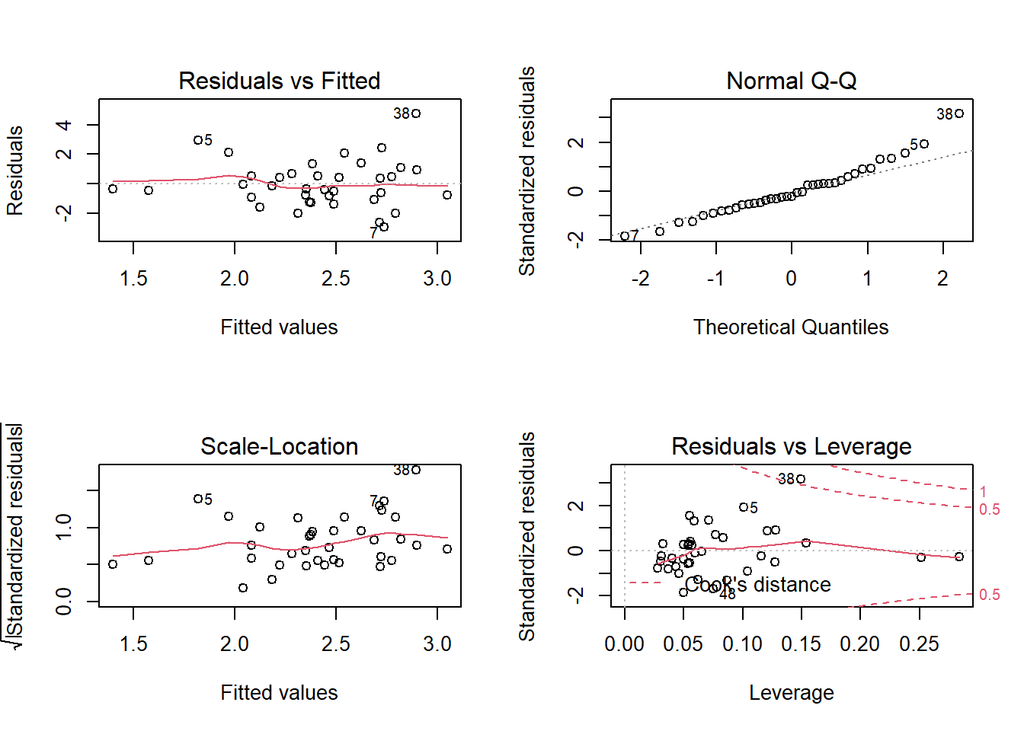

```r
par(mfrow=c(2,2))
plot(lm_white)
```

```r
anova(lm_white)
```

|  | Df | Sum Sq | Mean Sq | F value | Pr(>F) |
| --- | --- | --- | --- | --- | --- |
| precipitation | 1 | 4.72542906 | 4.72542906 | 1.77399505 | 0.1917486 |
| tasmin | 1 | 0.06847507 | 0.06847507 | 0.02570654 | 0.8735679 |
| Residuals | 34 | 90.56653679 | 2.66372167 | NA | NA |

#### orange morph

```r
lm_orange<-lm(logit(females_orange)~precipitation+tasmin,data=relative_freq)
summary(lm_orange)
```

```
##
## Call:
## lm(formula = logit(females_orange) ~ precipitation + tasmin,
##     data = relative_freq)
##
## Residuals:
##     Min      1Q  Median      3Q     Max
## -1.6507 -1.0152 -0.2755  0.7027  3.2571
##
## Coefficients:
##                 Estimate Std. Error t value Pr(>|t|)
## (Intercept)   -17.869138 141.931744  -0.126    0.903
## precipitation  -0.827231   3.126774  -0.265    0.797
## tasmin          0.007505   0.046065   0.163    0.874
##
## Residual standard error: 1.56 on 9 degrees of freedom
##   (37 observations deleted due to missingness)
## Multiple R-squared:  0.01528,    Adjusted R-squared:  -0.2035
## F-statistic: 0.06982 on 2 and 9 DF,  p-value: 0.9331
```

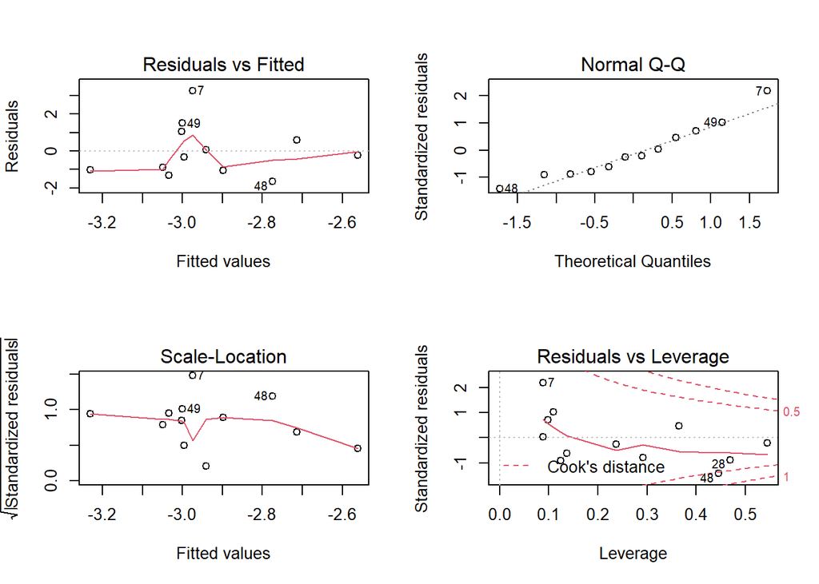

```r
par(mfrow=c(2,2))
plot(lm_orange)
```

```r
anova(lm_orange)
```

|  | Df | Sum Sq | Mean Sq | F value | Pr(>F) |
| --- | --- | --- | --- | --- | --- |
| precipitation | 1 | 0.27528225 | 0.27528225 | 0.11309544 | 0.7443553 |
| tasmin | 1 | 0.06460574 | 0.06460574 | 0.02654227 | 0.8741825 |
| Residuals | 9 | 21.90663208 | 2.43407023 | NA | NA |

Precipitation mainly influences the frequency change of the black morph

#### visualization of the chelsa linear models

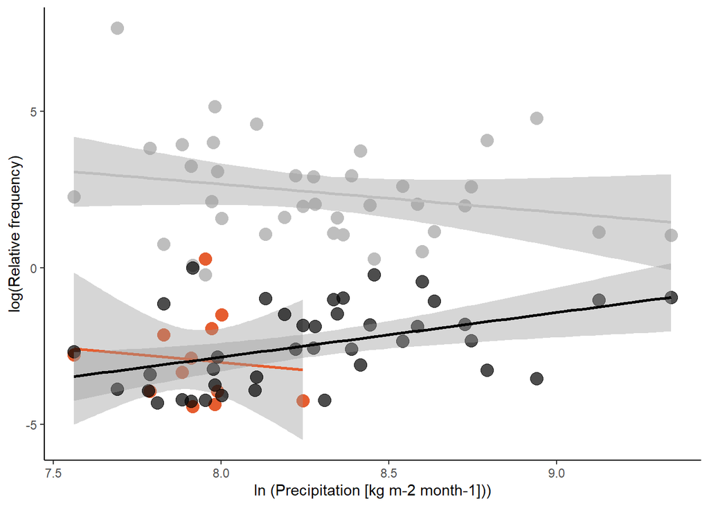

```r
library(tidyverse)
o_col<-"#e65d2f"
w_col<-"gray"
b_col<-"black"
ggplot(relative_freq,aes(precipitation, logit(females_white))) +
  geom_point(aes(precipitation, logit(females_white)),col=w_col,size=4) +
  geom_smooth(aes(precipitation,logit(females_white)),method='lm', formula= y~x,col=w_col)+
  geom_point(aes(precipitation, logit(females_orange)),col=o_col,size=4) +
  geom_smooth(aes(precipitation,logit(females_orange)),method='lm', formula= y~x,col=o_col)+
  geom_point(aes(precipitation, logit(females_black)),col=b_col,size=4,alpha=0.7) +
  geom_smooth(aes(precipitation,logit(females_black)),method='lm', formula= y~x,col=b_col)+
  theme_classic()+labs(y="log(Relative frequency)",x="ln (Precipitation [kg m-2 month-1]))")#+scale_colour_manual(values = c("Black" = b_col,"White-Black" = w_col, "Orange" = o_col))
```

### AWAP Linear models significant variables

According to the Multiple Regression on distance Matrices Precipitation seems to influence the change in colour among localities. Let’s explore individually the effect of this variables

Calculate frequencies relative frequencies

```r
relative_freq<-data.frame(females_white=numeric(),females_orange=numeric(),females_black=numeric())
morphs<-c("females_white","females_orange","females_black")
for(i in 1:nrow(sites_freq)){
total<-sum(sites_freq[i,morphs])
freq<-as.numeric(sites_freq[i,morphs]/total)
relative_freq[i,]<-freq
}
```

add a column with the precipitation

```r
relative_freq[relative_freq==0]<-NA
relative_freq$precipitation<-sites_freq$precipitation
relative_freq$max_temperature<-sites_freq$max_temperature
relative_freq$min_temperature<-sites_freq$min_temperature
```

linear models per colour morph

#### black morph

```r
lm_black<-lm(logit(females_black)~precipitation+max_temperature+min_temperature,data=relative_freq)
summary(lm_black)
```

```
##
## Call:
## lm(formula = logit(females_black) ~ precipitation + max_temperature +
##     min_temperature, data = relative_freq)
##
## Residuals:
##     Min      1Q  Median      3Q     Max
## -1.5725 -0.8589 -0.1492  0.7540  2.3695
##
## Coefficients:
##                 Estimate Std. Error t value Pr(>|t|)
## (Intercept)      0.07871    2.62922   0.030   0.9763
## precipitation    0.45611    0.40354   1.130   0.2658
## max_temperature -0.32720    0.14492  -2.258   0.0301 *
## min_temperature  0.34608    0.17634   1.963   0.0575 .
## ---
## Signif. codes:  0 '***' 0.001 '**' 0.01 '*' 0.05 '.' 0.1 ' ' 1
##
## Residual standard error: 1.078 on 36 degrees of freedom
##   (9 observations deleted due to missingness)
## Multiple R-squared:  0.3588, Adjusted R-squared:  0.3053
## F-statistic: 6.714 on 3 and 36 DF,  p-value: 0.001027
```

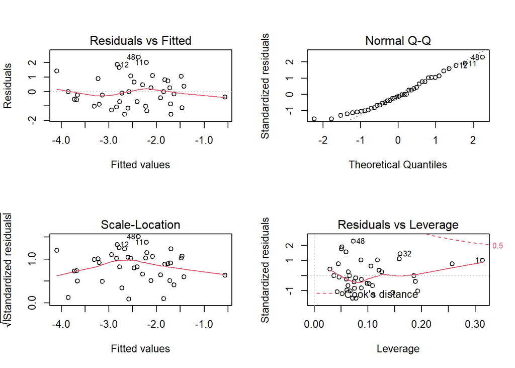

```r
par(mfrow=c(2,2))
plot(lm_black)
```

```r
anova(lm_black)
```

|  | Df | Sum Sq | Mean Sq | F value | Pr(>F) |
| --- | --- | --- | --- | --- | --- |
| precipitation | 1 | 17.159343 | 17.159343 | 14.777882 | 0.0004737967 |
| max_temperature | 1 | 1.757864 | 1.757864 | 1.513899 | 0.2265245915 |
| min_temperature | 1 | 4.472281 | 4.472281 | 3.851595 | 0.0574631026 |
| Residuals | 36 | 41.801414 | 1.161150 | NA | NA |

#### white-black morph

```r
lm_white<-lm(logit(females_white)~precipitation+max_temperature+min_temperature,data=relative_freq)
summary(lm_white)
```

```
##
## Call:
## lm(formula = logit(females_white) ~ precipitation + max_temperature +
##     min_temperature, data = relative_freq)
##
## Residuals:
##     Min      1Q  Median      3Q     Max
## -3.2253 -1.2975 -0.0065  0.9368  3.9453
##
## Coefficients:
##                 Estimate Std. Error t value Pr(>|t|)
## (Intercept)     -1.52630    4.06017  -0.376    0.709
## precipitation   -0.29516    0.62508  -0.472    0.640
## max_temperature  0.24661    0.22670   1.088    0.285
## min_temperature -0.07375    0.26765  -0.276    0.785
##
## Residual standard error: 1.609 on 33 degrees of freedom
##   (12 observations deleted due to missingness)
## Multiple R-squared:  0.1043, Adjusted R-squared:  0.0229
## F-statistic: 1.281 on 3 and 33 DF,  p-value: 0.297
```

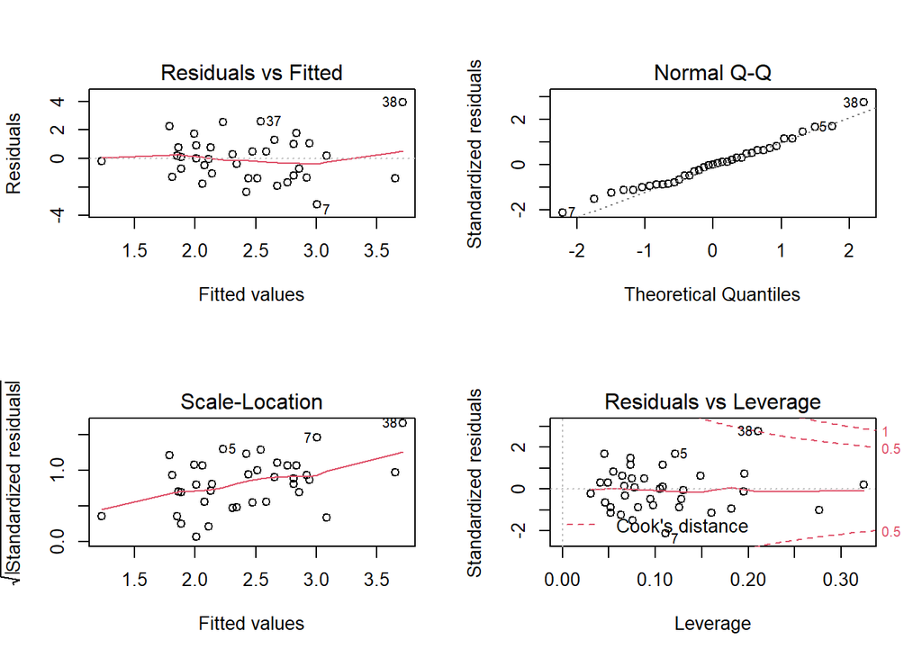

```r
par(mfrow=c(2,2))
plot(lm_white)
```

```r
anova(lm_white)
```

|  | Df | Sum Sq | Mean Sq | F value | Pr(>F) |
| --- | --- | --- | --- | --- | --- |
| precipitation | 1 | 5.4915032 | 5.4915032 | 2.12171290 | 0.1546739 |
| max_temperature | 1 | 4.2605173 | 4.2605173 | 1.64610567 | 0.2084278 |
| min_temperature | 1 | 0.1964846 | 0.1964846 | 0.07591435 | 0.7846304 |
| Residuals | 33 | 85.4119358 | 2.5882405 | NA | NA |

#### orange morph

```r
lm_orange<-lm(logit(females_orange)~precipitation+max_temperature+min_temperature,data=relative_freq)
summary(lm_orange)
```

```
##
## Call:
## lm(formula = logit(females_orange) ~ precipitation + max_temperature +
##     min_temperature, data = relative_freq)
##
## Residuals:
##     Min      1Q  Median      3Q     Max
## -1.2974 -0.4815 -0.3053  0.5774  1.8209
##
## Coefficients:
##                 Estimate Std. Error t value Pr(>|t|)
## (Intercept)      7.48795   15.32957   0.488    0.638
## precipitation   -1.76816    2.68489  -0.659    0.529
## max_temperature  0.05275    0.61993   0.085    0.934
## min_temperature -0.93002    0.53619  -1.735    0.121
##
## Residual standard error: 1.178 on 8 degrees of freedom
##   (37 observations deleted due to missingness)
## Multiple R-squared:  0.5006, Adjusted R-squared:  0.3133
## F-statistic: 2.673 on 3 and 8 DF,  p-value: 0.1184
```

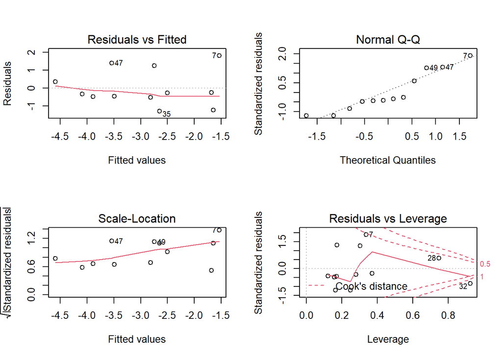

```r
par(mfrow=c(2,2))
plot(lm_orange)
```

```r
anova(lm_orange)
```

|  | Df | Sum Sq | Mean Sq | F value | Pr(>F) |
| --- | --- | --- | --- | --- | --- |
| precipitation | 1 | 6.4471157 | 6.4471157 | 4.6421815 | 0.06332264 |
| max_temperature | 1 | 0.5106696 | 0.5106696 | 0.3677026 | 0.56106774 |
| min_temperature | 1 | 4.1782416 | 4.1782416 | 3.0085013 | 0.12105120 |
| Residuals | 8 | 11.1104931 | 1.3888116 | NA | NA |

#### visualization of the linear models

##### Precipitation

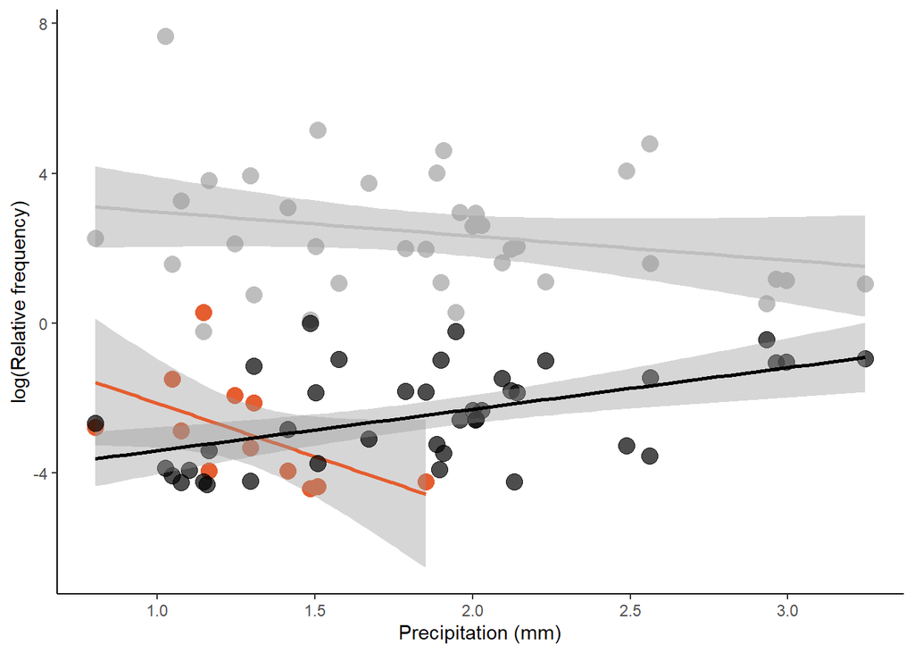

```r
library(tidyverse)
o_col<-"#e65d2f"
w_col<-"gray"
b_col<-"black"
ggplot(relative_freq,aes(precipitation, logit(females_white))) +
  geom_point(aes(precipitation, logit(females_white)),col=w_col,size=4) +
  geom_smooth(aes(precipitation,logit(females_white)),method='lm', formula= y~x,col=w_col)+
  geom_point(aes(precipitation, logit(females_orange)),col=o_col,size=4) +
  geom_smooth(aes(precipitation,logit(females_orange)),method='lm', formula= y~x,col=o_col)+
  geom_point(aes(precipitation, logit(females_black)),col=b_col,size=4,alpha=0.7) +
  geom_smooth(aes(precipitation,logit(females_black)),method='lm', formula= y~x,col=b_col)+
  theme_classic()+labs(y="log(Relative frequency)",x="Precipitation (mm)")#+scale_colour_manual(values = c("Black" = b_col,"White-Black" = w_col, "Orange" = o_col))
```

##### Maximum temperature

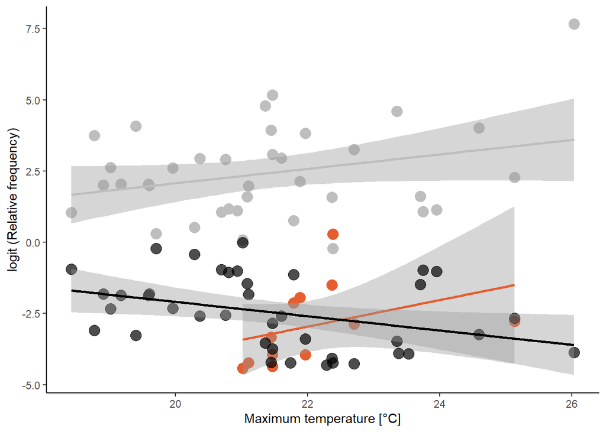

```r
library(tidyverse)
o_col<-"#e65d2f"
w_col<-"gray"
b_col<-"black"
ggplot(relative_freq,aes(max_temperature, logit(females_white))) +
  geom_point(aes(max_temperature, logit(females_white)),col=w_col,size=4) +
  geom_smooth(aes(max_temperature,logit(females_white)),method='lm', formula= y~x,col=w_col)+
  geom_point(aes(max_temperature, logit(females_orange)),col=o_col,size=4) +
  geom_smooth(aes(max_temperature,logit(females_orange)),method='lm', formula= y~x,col=o_col)+
  geom_point(aes(max_temperature, logit(females_black)),col=b_col,size=4,alpha=0.7) +
  geom_smooth(aes(max_temperature,logit(females_black)),method='lm', formula= y~x,col=b_col)+
  theme_classic()+labs(y="logit (Relative frequency)",x="Maximum temperature [°C]")#+scale_colour_manual(values = c("Black" = b_col,"White-Black" = w_col, "Orange" = o_col))
```

##### Minimum temperature

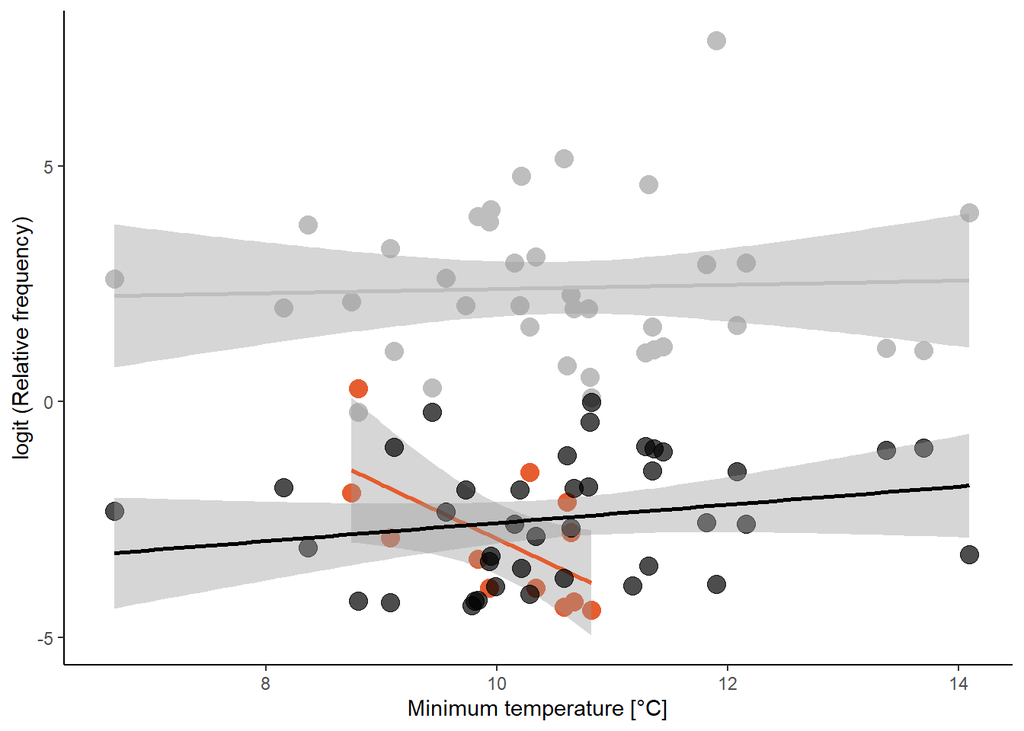

```r
library(tidyverse)
o_col<-"#e65d2f"
w_col<-"gray"
b_col<-"black"
ggplot(relative_freq,aes(min_temperature, logit(females_white))) +
  geom_point(aes(min_temperature, logit(females_white)),col=w_col,size=4) +
  geom_smooth(aes(min_temperature,logit(females_white)),method='lm', formula= y~x,col=w_col)+
  geom_point(aes(min_temperature, logit(females_orange)),col=o_col,size=4) +
  geom_smooth(aes(min_temperature,logit(females_orange)),method='lm', formula= y~x,col=o_col)+
  geom_point(aes(min_temperature, logit(females_black)),col=b_col,size=4,alpha=0.7) +
  geom_smooth(aes(min_temperature,logit(females_black)),method='lm', formula= y~x,col=b_col)+
  theme_classic()+labs(y="logit (Relative frequency)",x="Minimum temperature [°C]")#+scale_colour_manual(values = c("Black" = b_col,"White-Black" = w_col, "Orange" = o_col))
```

## Colour frequency on map

Load libraries

```r
#Load libraries

library(plotrix)

library(raster)

library(maptools)

library(tidyverse)

library("rnaturalearth")

library(RColorBrewer)
```

map of Australia

```r
library("rworldmap")
library(sf)
map_world <- getMap(resolution = "high")
aus_map<-st_as_sf(map_world[which(map_world$ISO3=="AUS"),])
aus_map<-aus_map[1]
```

load chelsa variables

```r
chelsa_variables <- stack(list.files(path = "chelsea", pattern = ".tif", full.names = TRUE))

# Extract variable names from file names
names_variables <- list.files(path = "chelsea", pattern = ".tif$", full.names = TRUE) %>%
                    str_match(pattern = "\\w+.tif$") %>%
                    gsub(pattern = ".tif", replacement = "") %>%
                    as.vector()

# Assign descriptive names to the raster layers
names(chelsa_variables) <- paste0("chelsa_", names_variables)
```

For better visualization let’s divide the map of Australia in two western and easter

### Western Australia frequency colours

Cut the precipitation layer around the sites

```r
#paleta <- colorRampPalette(c("#B47067", "#EDEDEB"))
paleta <- colorRampPalette(c("#F4E8C5", "#F1D98F","#F6EC3C","#CDDC43","#A5CE39","#7DC243","#4EB29E","#467FC1","#3952A4","#6F4A96"))
wa<-sites_freq %>% filter(state=="WA") %>% data.frame()
extent_sub <-extent(min(wa[,"X"])-1, max(wa[,"X"]+1), min(wa[,"Y"])-0.25, max(wa[,"Y"])+0.25)
#select the raster
pos_var<-which(grepl(pattern="pr",x=names(chelsa_variables))==TRUE)
int_var <- terra::mask(chelsa_variables[[pos_var]], aus_map)
int_var <- crop(int_var, extent_sub)
```

Plot the map

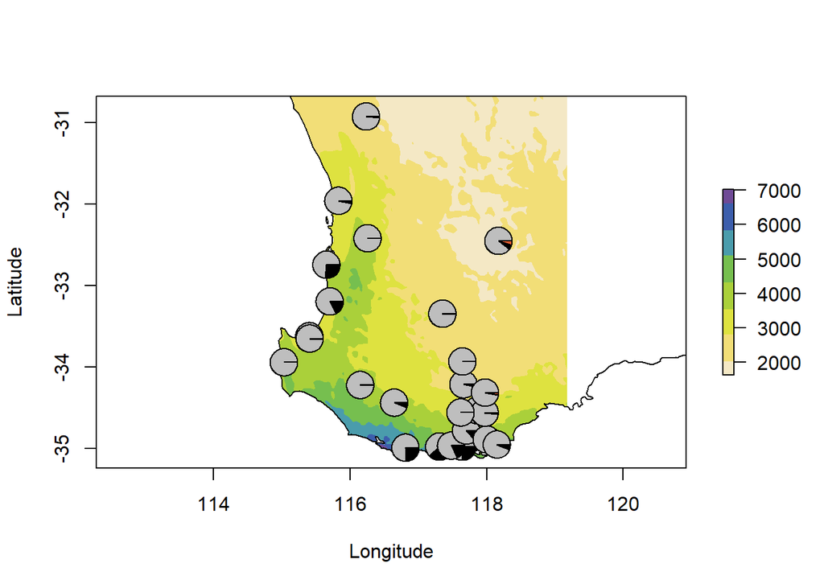

```r
library(plotrix)
library(RColorBrewer)

plot(int_var, xlim=extent_sub[c(1,2)], ylim=extent_sub[c(3,4)], col = paleta(8), axes=T, xlab="Longitude", ylab="Latitude")

#Add the shape file
plot(aus_map[1], xlim=extent_sub[c(1,2)], ylim=extent_sub[c(3,4)],col=NA,add=T)

#Now the points
points(wa[,"X"], wa[,"Y"], pch=19, col="black", cex=2)

colours=alpha(c("gray","black","#e65d2f"),1)
for(i in 1:nrow(wa)){
total_ind=sum(wa[i,grep(pattern="females",x=names(wa))])
freq<-as.numeric(wa[i,grep(pattern="females",x=names(wa))]/total_ind)
floating.pie(xpos=wa[i,"X"],ypos=wa[i,"Y"],x=freq,radius=0.2,col=colours)
 }
```

### Eastern Australia frequency colours

Cut the precipitation layer aroudn the sites

```r
wa<-sites_freq %>% filter(state!="WA") %>% data.frame()
extent_sub <-extent(min(wa[,"X"])-1, max(wa[,"X"]+1), min(wa[,"Y"])-1, max(wa[,"Y"])+1)
#select the raster
pos_var<-which(grepl(pattern="pr",x=names(chelsa_variables))==TRUE)
int_var <- terra::mask(chelsa_variables[[pos_var]], aus_map)
int_var <- crop(int_var, extent_sub)
```

Plot the map

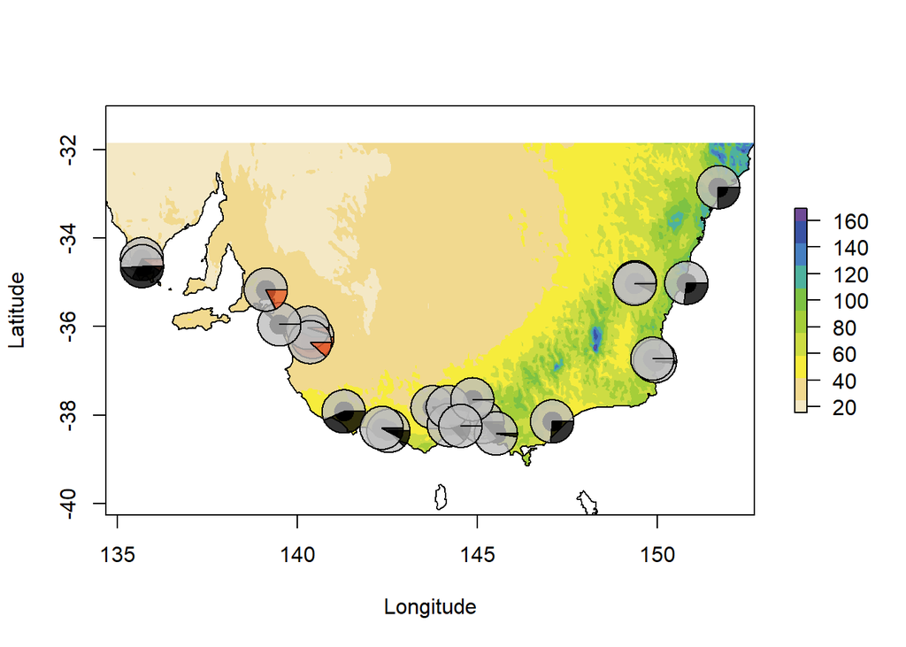

```r
values(int_var)<-values(int_var)/100
plot(int_var, xlim=extent_sub[c(1,2)], ylim=extent_sub[c(3,4)], col = paleta(10), axes=T, xlab="Longitude", ylab="Latitude")

#Add the shape file
plot(aus_map[1], xlim=extent_sub[c(1,2)], ylim=extent_sub[c(3,4)],col=NA,add=T)

#Now the points
points(wa[,"X"], wa[,"Y"], pch=19, col="black", cex=2)

colours=alpha(c("gray","black","#e65d2f"),0.8)
for(i in 1:nrow(wa)){
total_ind=sum(wa[i,grep(pattern="females",x=names(wa))])
freq<-as.numeric(wa[i,grep(pattern="females",x=names(wa))]/total_ind)
floating.pie(xpos=wa[i,"X"],ypos=wa[i,"Y"],x=freq,radius=0.6,col=colours)
 }
```